# apresentacao_inicial

Murilo, Caio e Isabella

2023-11-18

# Apresentação Inicial

Apresentação da base de dados que será utilizada para o projeto final de Aprendizado de Maquina II.

link para a base de dados: https://www.kaggle.com/datasets/surajjha101/stores-area-and-sales-data

## Contexto

A base de dados compreende dados de 896 supermercados localizados nos Estados Unidos. O foco principal desta pesquisa é prever a receita de cada loja com base em diversas informações disponíveis. Além disso, temos como segundo objetivo analisar se a clusterização das lojas em grupos, que serão identificados posteriormente, influencia positivamente nos resultados das previsões de receita.

Dessa forma, conduziremos duas abordagens distintas de modelagem. Na primeira, empregaremos o método K-means para agrupar as lojas, sendo que cada grupo será submetido a uma regressão específica. Na segunda abordagem, aplicaremos métodos de regressão sem a clusterização prévia das lojas. Ao término do estudo, procederemos à comparação do desempenho dessas duas estratégias.

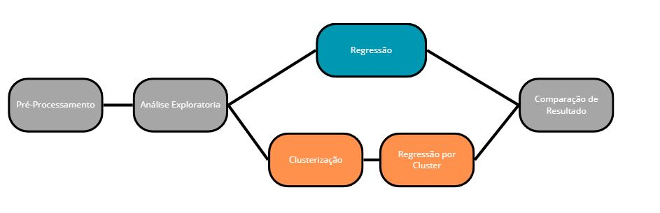

Fluxo de Trabalho

## Entrega I

Códigos para responder as informações pedidas na entrega I.

```r
# Lendo arquivo CSV
df <- read.csv("Stores.csv")

# Visualizando as 10 primeiras linhas
head(df, 10)
```

```
##    Store.ID Store_Area Items_Available Daily_Customer_Count Store_Sales
## 1         1       1659            1961                  530       66490
## 2         2       1461            1752                  210       39820
## 3         3       1340            1609                  720       54010
## 4         4       1451            1748                  620       53730
## 5         5       1770            2111                  450       46620
## 6         6       1442            1733                  760       45260
## 7         7       1542            1858                 1030       72240
## 8         8       1261            1507                 1020       37720
## 9         9       1090            1321                  680       46310
## 10       10       1030            1235                 1130       44150
```

- Número de linhas

```r
# Obtendo o número de linhas
nrow(df)
```

```
## [1] 896
```

Existem 896 linhas que represental lojas distintas.

- Número de Colunas

```r
ncol(df)
```

```
## [1] 5
```

Existem 5 colunas nesta base de dados:

1. *Store ID*: (Index) ID de cada loja.
2. *Store_Area*: Área física da loja em jardas quadradas.
3. *Items_Available*: Numero de produtos distintos a venda na loja.
4. *DailyCustomerCount*: Numero médio de consumidores por mês.
5. *Store_Sales*: Faturamento em (US $).
- Valores Nulos

```r
# Obtendo o número de valores núlos em cada coluna
colSums(is.na(df))
```

```
##             Store.ID           Store_Area      Items_Available
##                    0                    0                    0
## Daily_Customer_Count          Store_Sales
##                    0                    0
```

Não existem valores nulos nesta base de dados.

- Classe de cada coluna

```r
# Obtendo o tipo de cada coluna
sapply(df, class)
```

```
##             Store.ID           Store_Area      Items_Available
##            "integer"            "integer"            "integer"
## Daily_Customer_Count          Store_Sales
##            "integer"            "integer"
```

- Abordagem não supervisionada

A estratégia não supervisionada selecionada foi algoritmo K-means. Este método será empregado com o intuito de determinar o número ideal de clusters e, simultaneamente, agrupar as lojas com base em características específicas fornecidas. Essas características incluem o tamanho da loja em jardas quadradas, o número de produtos distintos disponíveis para venda e a média mensal de consumidores.

- Abordagem supervisionada

Na modelagem supervisionada, adotaremos as duas abordagens previamente discutidas, aplicando os algoritmos tanto à base de dados completa quanto às bases de dados segmentadas pela clusterização. Para a definição do modelo de regressão, compararemos métodos como a regressão linear simples, a regressão com penalização Lasso e Ridge, além de métodos baseados em árvores de decisão, como Random Forest e Gradient Boosting. Durante o processo de modelagem, os hiperparâmetros serão otimizados com o objetivo de alcançar a melhor precisão possível nas previsões.

Algoritimos selecionados:

1. Regressão Linear Simples
2. Regresssão Linear Lasso
3. Regressão Linear Ridge
4. Floresta Aleatória
5. Gradient Boosting